[figure not shown]

# SIFT like local features

Faisal Qureshi  
Professor  
Faculty of Science  
Ontario Tech University  
Oshawa ON Canada  
http://vclab.science.ontariotechu.ca

## Copyright information

© Faisal Qureshi

## License

This work is licensed under a [Creative Commons Attribution-NonCommercial 4.0 International License](http://creativecommons.org/licenses/by-nc/4.0/).

## Outline

- Image derivatives
- Image gradients
- Gradient magnitudes and angles
- Quantization
- Histogram computation

## Tasks

### 1

Complete the various steps needed to compute the rotation invariant descriptor. You can use the following image to test your code

```
DATA_FOLDER = 'data'
img = cv.imread(os.path.join(DATA_FOLDER, 'local-features-construction-2.jpg'), 0)
img = cv.resize(img, (256, 256))

plt.figure(figsize=(5,5))
plt.imshow(img, cmap='gray');
plt.plot([74],[175],'r.')
```

### 2

Combine this code in the following method

```
descriptor, I_patch, grad_patch, grad_patch_weighted, grad_color_patch = my_local_descriptor(img, r, c)
```

This method takes in an image `img` and row `r` and column `c` location. The method returns a 128-dimensional descriptor. It should also return $4$ $16\times16$ patches around `(r,c)` locations. `I_patch` is image intensity patch, `grad_patch` is gradient magnitudes, `grad_patch_weighted` is weighted gradient magnitudes, and `grad_color_patch` returns the colorized gradient magnitudes.

### 3

Use this method to compute descriptors as follows:

```
DATA_FOLDER = 'data'
img1 = cv.imread(os.path.join(DATA_FOLDER, 'local-features-construction-2.jpg'), 0)
img1 = cv.resize(img1, (256, 256))

img2 = cv.imread(os.path.join(DATA_FOLDER, 'local-features-construction-1.jpg'), 0)
img2 = cv.resize(img2, (256, 256))

desc1, p1, g1, gw1, gc1 = my_local_descriptor(img1, 175, 74)
desc2, p2, g2, gw2, gc2 = my_local_descriptor(img2, 197, 106)
desc3, p3, g3, gw3, gc3 = my_local_descriptor(img2, 100, 54)
```

### 4

Next compute the distances between the three descriptors as follows:

```
X = np.vstack([desc1, desc2, desc3])

from scipy.spatial import distance_matrix
distance_matrix(X, X)
```

### 5

Comment whether or not desc1 is closer to desc2 than to desc3.

## Starter code

```python
import cv2 as cv
import numpy as np
import scipy as sp
from scipy import signal
import matplotlib.pyplot as plt
import matplotlib.cm as cm
import os
```

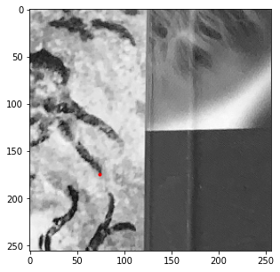

```python
DATA_FOLDER = 'data'
img = cv.imread(os.path.join(DATA_FOLDER, 'local-features-construction-2.jpg'), 0)
img = cv.resize(img, (256, 256))

plt.figure(figsize=(5,5))
plt.imshow(img, cmap='gray')
plt.plot([74],[175],'r.');
```

### Image derivatives

```python
# %load solutions/05-sift-like-local-features/lab-5-solution-image-derivatives.py
```

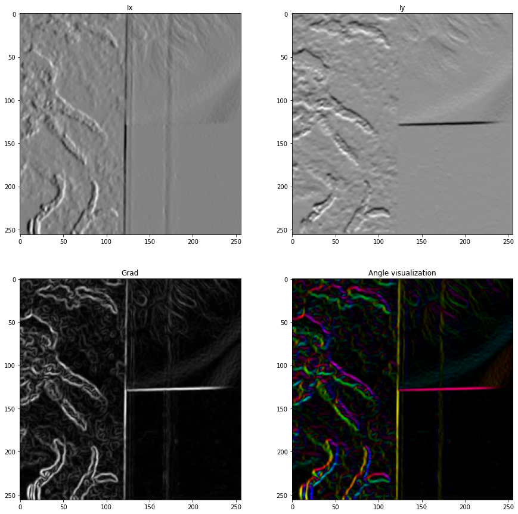

```python
plt.figure(figsize=(15,15))
plt.subplot(221)
plt.title('Ix')
plt.imshow(Ix, cmap='gray')
plt.subplot(222)
plt.title('Iy')
plt.imshow(Iy, cmap='gray');
plt.subplot(223)
plt.title('Grad')
plt.imshow(Igrad, cmap='gray')
plt.subplot(224)
plt.title('Angle visualization')
plt.imshow(Igrad_color);
```

### 16x16 window patch

Extract a $16x16$ window around location $(x,y)$. Notice how images are stored in numpy. Unlike the 2D $xy$ coordinate system that we are used to, here $x$ corresponds to columns and increase from left to right. $y$ corresponds to rows and increase from top to bottom.

```python
# %load solutions/05-sift-like-local-features/lab-5-solution-patch.py
```

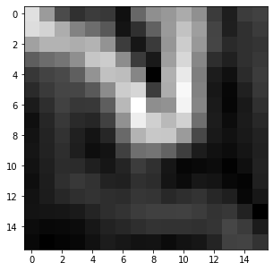

```python
plt.figure(figsize=(5,5))
plt.imshow(grad_patch, cmap='gray');
```

### Weighted gradient magnitudes

Get gradient magnitude and multiply it by a $16 \times 16$ Gaussian window of $\sigma=2.5$

```python
# %load solutions/05-sift-like-local-features/lab-5-solution-weighted-grad.py
```

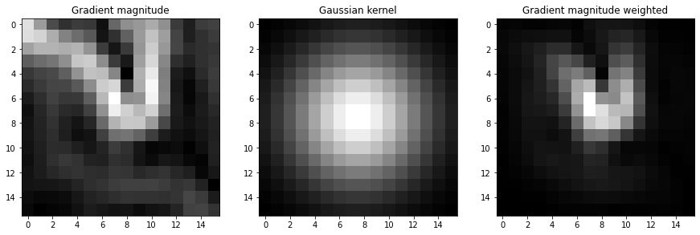

```python
plt.figure(figsize=(15,5))
plt.subplot(131)
plt.title('Gradient magnitude')
plt.imshow(grad_patch, cmap='gray')
plt.subplot(132)
plt.title('Gaussian kernel')
plt.imshow(g, cmap='gray')
plt.subplot(133)
plt.title('Gradient magnitude weighted')
plt.imshow(grad_patch_weighted, cmap='gray');
```

### Finding dominant angle

Quantize angles to 36 bins (from 0 to 360 degrees). Find the dominant angle (the angle that is most repeated). Subtract dominant angle from every angle to achieve rotation invariant.

```python
# %load solutions/05-sift-like-local-features/lab-5-solution-dominant-angle.py
```

### Construct feature descriptor

Divide $16 \times 16$ into $16$ blocks. Each block is $4 \tiems 4$. Within each block, quantize angles into 8 bins (from 0 to 360 degrees). Computed gradient magnitude weighted, normalized, angle histograms. Each block thus returns an $8$-dimensional vector. Concatenate $16$ $8$-dimensional vectors to construct a $128$-dimensional vector.

```python
# %load solutions/05-sift-like-local-features/lab-5-solution-feature-descriptor.py
```

### Putting it all together

Now put the code together in one convenient function that computes the 128 dimensional descriptor at a particular location of a given grayscale image.

```python
# %load solutions/05-sift-like-local-features/lab-5-solution-my-local-descriptor.py
```

```python
def my_local_descriptor(img, r, c):

    descriptor = None
    I_patch = None
    grad_patch = None
    grad_patch_weighted = None
    grad_color_patch = None

    return descriptor, I_patch, grad_patch, grad_patch_weighted, grad_color_patch
```

### Check for rotation invariance

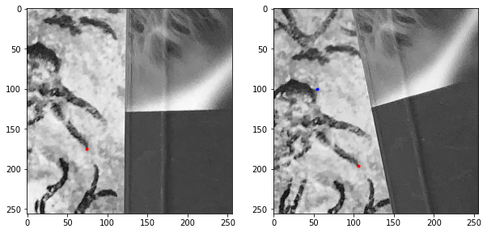

```python
DATA_FOLDER = 'data'
img1 = cv.imread(os.path.join(DATA_FOLDER, 'local-features-construction-2.jpg'), 0)
img1 = cv.resize(img1, (256, 256))

img2 = cv.imread(os.path.join(DATA_FOLDER, 'local-features-construction-1.jpg'), 0)
img2 = cv.resize(img2, (256, 256))

plt.figure(figsize=(10,5))
plt.subplot(121)
plt.imshow(img1, cmap='gray');
plt.plot([74],[175],'r.')
plt.subplot(122)
plt.imshow(img2, cmap='gray');
plt.plot([106],[196],'r.');
plt.plot([54],[100],'b.');
```

```python
desc1, p1, g1, gw1, gc1 = my_local_descriptor(img1, 175, 74)
desc2, p2, g2, gw2, gc2 = my_local_descriptor(img2, 197, 106)
desc3, p3, g3, gw3, gc3 = my_local_descriptor(img2, 100, 54)
```

[output not shown]

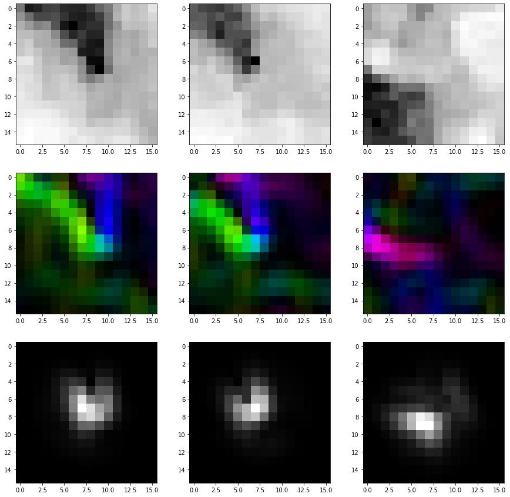

```python
plt.figure(figsize=(15, 15))
plt.subplot(331)
plt.imshow(p1, cmap='gray')
plt.subplot(332)
plt.imshow(p2, cmap='gray')
plt.subplot(333)
plt.imshow(p3, cmap='gray')
plt.subplot(334)
plt.imshow(gc1, cmap='gray')
plt.subplot(335)
plt.imshow(gc2, cmap='gray')
plt.subplot(336)
plt.imshow(gc3, cmap='gray')
plt.subplot(337)
plt.imshow(gw1, cmap='gray')
plt.subplot(338)
plt.imshow(gw2, cmap='gray')
plt.subplot(339)
plt.imshow(gw3, cmap='gray');
```

```python
# %load solutions/05-sift-like-local-features/lab-5-solution-computing-distance.py
```

## Submission

Include code and results on the images found in the above folder in a single jupyter notebook. *Submit via canvas.*

[figure not shown]